# Illustrate Some Correlation Limitations and Fallacies in R

Author: Rick Dean

Article date: 2021-03-12

Abstract

The following are notes and R scripts inspired by the article [Illustrate Some Correlation Limitations and Fallacies in R](http://svmiller.com/blog/2020/01/illustrate-correlation-fallacies-limitations-in-r/) by Steve Miller.

```r
library(knitr)
library(kableExtra)
library(data.table)
library(ggplot2)
library(ggrepel)
library(RplotterPkg)
library(RregressPkg)
library(here)

current_dir <- here()
```

## Anscombe’s Quartet

### Anscombe’s stats

Anscombe has 4 data sets, each with 2 variables, 11 observations, same means, same variance, same regression line, same residual sum of squares, same correlation.

```r
data("anscombe")
anscombe_dt <- data.table::data.table(anscombe)
anscombe_stats_dt <- data.table(
  var = colnames(anscombe_dt)
)
anscombe_stats_dt <- anscombe_stats_dt[, `:=`(
  mean = lapply(anscombe_dt, function(x) format(mean(x),digits = 4,nsmall=4)),
  sd = lapply(anscombe_dt, function(x) format(sd(x),digits = 4,nsmall=4)))]

RplotterPkg::create_table(
  x = anscombe_stats_dt,
  col_names = c("Variable","Mean","Standard Deviation"),
  head_bkgd = "purple",
  head_col = "white",
  align_v = c("l","c","c")
)
```

| Variable | Mean | Standard Deviation |
| --- | --- | --- |
| x1 | 9.0000 | 3.3166 |
| x2 | 9.0000 | 3.3166 |
| x3 | 9.0000 | 3.3166 |
| x4 | 9.0000 | 3.3166 |
| y1 | 7.5009 | 2.0316 |
| y2 | 7.5009 | 2.0317 |
| y3 | 7.5000 | 2.0304 |
| y4 | 7.5009 | 2.0306 |

### Anscombe’s plots

1. “Melt” *anscombe_dt* to give us a data.table with three columns (*Quartet*, *X*, *Y*).

```r
anscombe_melt_dt <- data.table::melt(anscombe_dt, measure = patterns("^x","^y"),value.name = c("X","Y"))
anscombe_melt_dt <-  anscombe_melt_dt[, .(Quartet = paste0("Quartet ", variable), X = X, Y = Y)]
```

2. Define the OLS fits and confidence intervals:

```r
all_ols_dt <- anscombe_melt_dt[,{
  X_vals = seq(min(.SD$X), max(.SD$X), 0.5)
  ols_df = RregressPkg::ols_predict_calc(
    df = .SD,
    formula_obj = Y ~ X,
    predictors_df = data.frame(X = X_vals)
  )
  .(X = X_vals, fit = ols_df$fit, lwr = ols_df$lwr, upr = ols_df$upr)
}, by = Quartet]
```

2. Plot the points, fitted lines, and the confidence intervals:

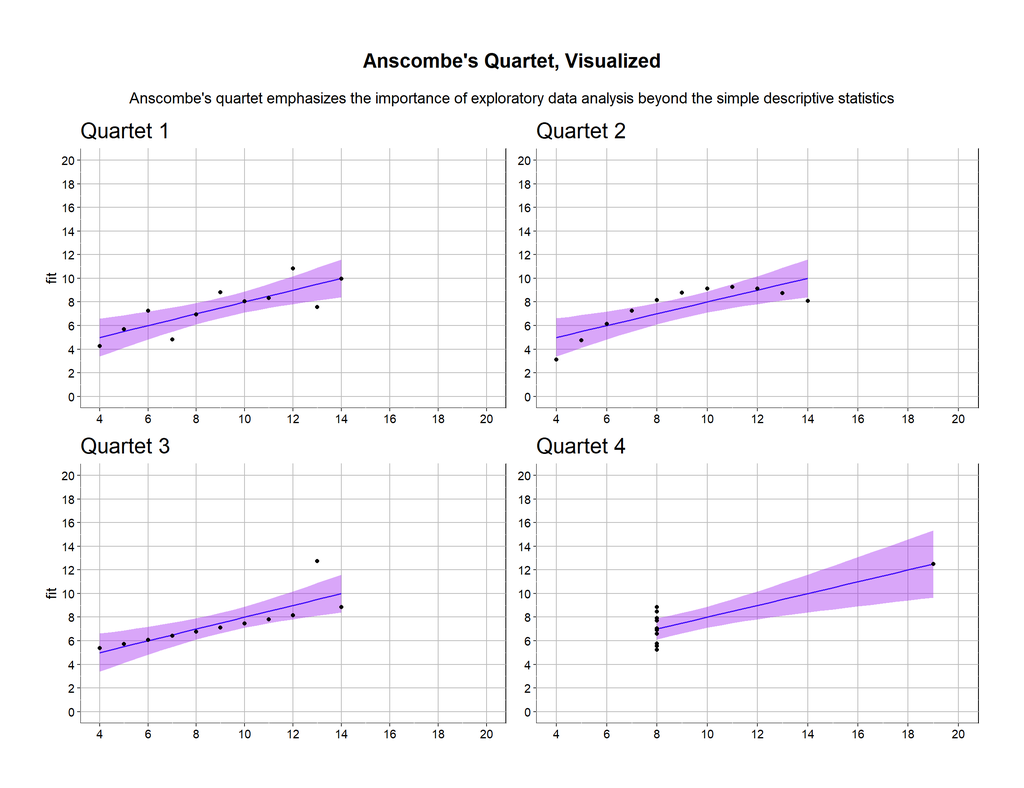

```r
add_on <- c(
  geom_point(data = anscombe_melt_dt[Quartet == "Quartet 1"], aes(x = X, y = Y)),
  geom_point(data = anscombe_melt_dt[Quartet == "Quartet 2"], aes(x = X, y = Y)),
  geom_point(data = anscombe_melt_dt[Quartet == "Quartet 3"], aes(x = X, y = Y)),
  geom_point(data = anscombe_melt_dt[Quartet == "Quartet 4"], aes(x = X, y = Y))
)
RplotterPkg::multi_scatter_plot(
  df = all_ols_dt,
  factor_var = "Quartet",
  factor_x = "X",
  aes_y = "fit",
  CI_lwr = "lwr",
  CI_upr = "upr",
  CI_type = "ribbon",
  CI_color = "purple",
  connect = T,
  show_pts = F,
  col_width = 6,
  x_limits = c(4,20),
  x_major_breaks = seq(4,20,2),
  y_limits = c(0,20),
  y_major_breaks = seq(0,20,2),
  show_minor_grids = F,
  rot_y_tic_label = T,
  line_color = "blue",
  title = "Anscombe's Quartet, Visualized",
  subtitle = "Anscombe's quartet emphasizes the importance of exploratory data analysis beyond the simple descriptive statistics",
  add_ons = add_on
)
```

## Simpson’s Paradox

Mr. Miller describes Simpson’s Paradox as…

> Simpson’s paradox is a well-known problem of correlation in which a correlation analysis, almost always done in a bivariate context, may reveal a relationship that is reversed upon the introduction of some third variable.

Wikipedia describes Simpson’s Paradox as…

> …a phenomenon in probability and statistics, in which a trend appears in several different groups of data but disappears or reverses when these groups are combined.

### State expenditures versus average SAT score

We illustrate Simpson’s Paradox with data from the paper [Getting What You Pay For](https://www.uvm.edu/~dguber/research/JSE99.pdf) by Deborah Lynn Guber, The University of Vermont.

1. Set up the data set:

```r
data_path <- file.path(current_dir, "Illustrate Some Correlation Limitations and Fallacies in R/data/Guber99.rda")
load(file = data_path)
guber_dt <- data.table::setDT(Guber99)
guber_dt <- guber_dt[, .(State = state, Expenditure = expendpp, AvgSAT = total, PercTakers = perctakers)]
```

2. Define the OLS fits and confidence intervals:

```r
guber_ols_dt <- guber_dt[,{
  Expenditure_vals = seq(min(Expenditure), max(Expenditure), 0.05)
  ols_df = RregressPkg::ols_predict_calc(
    df = guber_dt,
    formula_obj = AvgSAT ~ Expenditure,
    predictors_df = data.frame(Expenditure = Expenditure_vals)
  )
  .(Expenditure = Expenditure_vals, AvgSATFit = ols_df$fit, lwr = ols_df$lwr, upr = ols_df$upr)
}]
```

3. Plot the points, fitted lines, and the confidence intervals:

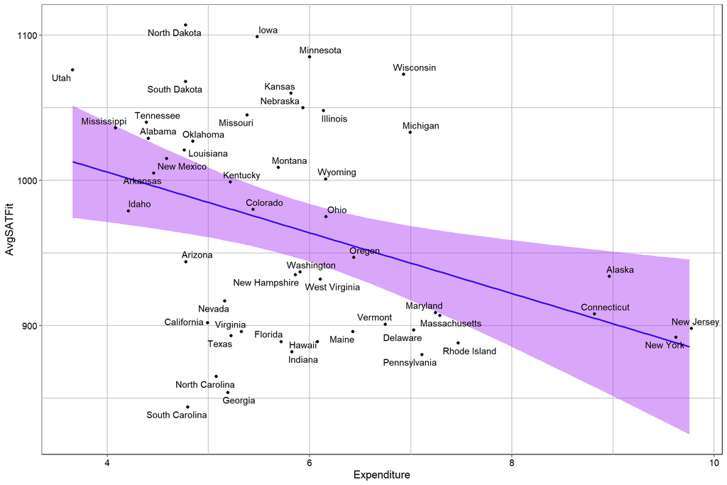

```r
RplotterPkg::create_scatter_plot(
  df = guber_ols_dt,
  aes_x = "Expenditure",
  aes_y = "AvgSATFit",
  connect = T,
  show_pts = F,
  rot_y_tic_label = T,
  CI_lwr = "lwr",
  CI_upr = "upr",
  CI_type = "ribbon",
  CI_color = "purple",
  line_color = "blue"
) + geom_point(data = guber_dt, aes(x = Expenditure, y = AvgSAT)) +
  ggrepel::geom_text_repel(data = guber_dt,aes(x = Expenditure, y = AvgSAT,label = State))
```

Take Away: There appears to be a negetive relationship between `Expenditure` and `AvgSat`

### Does the relation hold up across levels of state percent SAT takers

1. Break out percent SAT takers into four levels:

```r
guber_dt[, rank_takers := dplyr::ntile(guber_dt$PercTakers,4)]
guber_dt[, SAT_take :=
   fifelse(rank_takers == 1, "Lowest Quartile",
   fifelse(rank_takers == 2, "Second Quartile",
   fifelse(rank_takers == 3, "Third Quartile", "Highest Quartile")))]
guber_dt[, SAT_take := ordered(SAT_take, levels = c("Lowest Quartile","Second Quartile","Third Quartile","Highest Quartile"))]
```

2. Compute and show the correlation between *Expenditure* and *AvgSAT* across levels of *SAT_take*:

```r
guber_cor_dt <- guber_dt[, {
  exp_take_cor = cor(.SD$Expenditure, .SD$AvgSAT)
  .(Pearson_r = round(exp_take_cor,3))
}, by = SAT_take]

RplotterPkg::create_table(
  x = guber_cor_dt,
  caption = "SAT Test-Taker Percentage Quartile",
  head_bkgd = "purple",
  head_col = "white",
  full_width = T,
  align_v = c("l","c")
)
```

SAT Test-Taker Percentage Quartile

| SAT_take | Pearson_r |
| --- | --- |
| Lowest Quartile | 0.278 |
| Third Quartile | 0.570 |
| Second Quartile | 0.305 |
| Highest Quartile | 0.142 |

Take Away: The correlation between `Expenditure` and `AvgSAT` are all positive instead of negative across the participation groups.

### Plot `Expenditure` versus `AvgSAT` across the participation groups

1. Compute the OLS fits and confidence intervals across the groups

```r
takers_ols_dt <- guber_dt[,{
  Expenditure_vals = seq(min(.SD$Expenditure), max(.SD$Expenditure), 0.05)
  ols_df = RregressPkg::ols_predict_calc(
    df = .SD,
    formula_obj = AvgSAT ~ Expenditure,
    predictors_df = data.frame(Expenditure = Expenditure_vals)
  )
  .(Expenditure_fit = Expenditure_vals, AvgSAT_fit = ols_df$fit, lwr_fit = ols_df$lwr, upr_fit = ols_df$upr)
}, by = SAT_take]
```

2. Plot the groups:

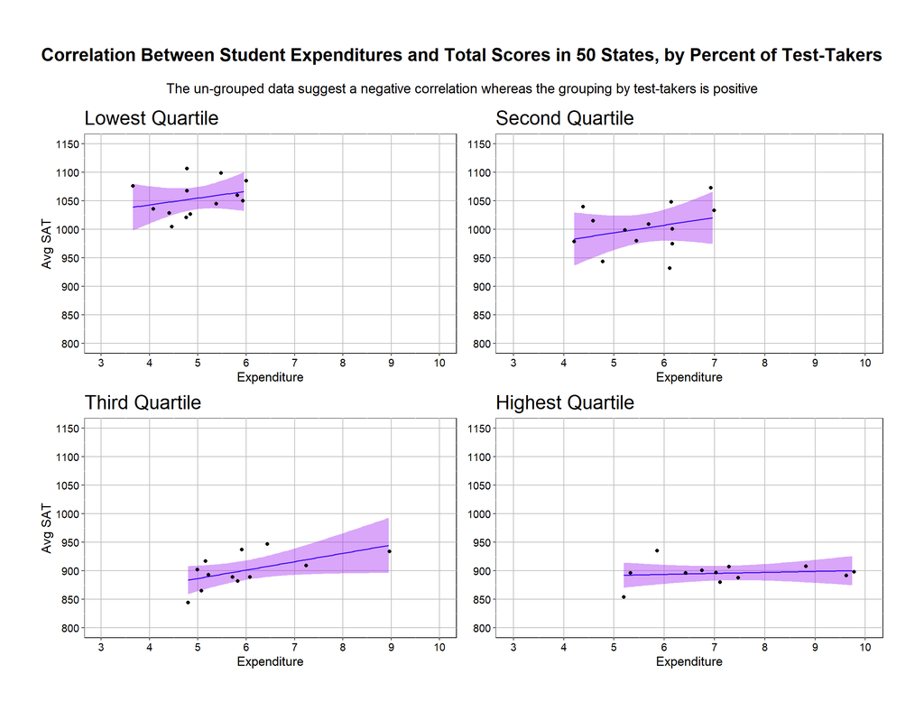

```r
add_on <- c(
  geom_point(data = guber_dt[SAT_take == "Lowest Quartile"], aes(x = Expenditure, y = AvgSAT)),
  geom_point(data = guber_dt[SAT_take == "Second Quartile"], aes(x = Expenditure, y = AvgSAT)),
  geom_point(data = guber_dt[SAT_take == "Third Quartile"], aes(x = Expenditure, y = AvgSAT)),
  geom_point(data = guber_dt[SAT_take == "Highest Quartile"], aes(x = Expenditure, y = AvgSAT))
)
RplotterPkg::multi_scatter_plot(
  df = takers_ols_dt,
  factor_var = "SAT_take",
  factor_x = "Expenditure_fit",
  aes_y = "AvgSAT_fit",
  CI_lwr = "lwr_fit",
  CI_upr = "upr_fit",
  CI_type = "ribbon",
  CI_color = "purple",
  connect = T,
  show_pts = F,
  col_width = 6,
  x_limits = c(3,10),
  x_major_breaks = seq(3,10,1),
  y_limits = c(800,1150),
  y_major_breaks = seq(800,1150,50),
  show_minor_grids = F,
  rot_y_tic_label = T,
  line_color = "blue",
  title = "Correlation Between Student Expenditures and Total Scores in 50 States, by Percent of Test-Takers",
  subtitle = "The un-grouped data suggest a negative correlation whereas the grouping by test-takers is positive",
  x_title = "Expenditure",
  y_titles = rep("Avg SAT", 4),
  add_ons = add_on
)
```

## Ecological Fallacy

Mr. Miller describes the ecological fallacy as …

> …inferences and correlations at the individual-level need not be equivalent at the group level.

### Illiteracy rates from the 1930 Census

1. Set up the data set:

```r
data_path <- file.path(current_dir, "Illustrate Some Correlation Limitations and Fallacies in R/data/illiteracy30.rda")
load(file = data_path)
illit_dt <- data.table::setDT(illiteracy30)
illit_dt <- illit_dt[, !c("state")]
```

2. Get the sums for each category:

```r
illit_sums_dt <- illit_dt[,lapply(illit_dt,sum)]
```

3. “Melt” *illit_sums_dt*:

```r
illit_melt_dt <- data.table::melt(illit_sums_dt, measure.vars = names(illit_sums_dt), variable.name = "Race", value.name = "Number")
```

4. Add a *category* and *literacy* columns:

```r
illit_melt_dt[, `:=`(category = c("Total Population", "Total Population",
                      "Native White", "Native White",
                      "White, Foreign/Mixed Parentage","White, Foreign/Mixed Parentage",
                      "Foreign-Born White", "Foreign-Born White",
                      "Black", "Black"),
                     literacy = rep(c("Total","Illiterate"),5))
              ]
```

5. Add *prop* for proportions:

```r
illit_melt_dt[, prop := round(.SD$Number/max(.SD$Number),3), by = category]
```

6. Show the proportions:

```r
RplotterPkg::create_table(
  x = illit_melt_dt[literacy != "Total", .(category, prop)],
  caption = "Illiteracy Rates in the 1930 U.S. Census",
  col_names = c("Group", "Proportion That is Illiterate"),
  head_bkgd = "purple",
  head_col = "white",
  full_width = T,
  align_v = c("l","c")
)
```

Illiteracy Rates in the 1930 U.S. Census

| Group | Proportion That is Illiterate |
| --- | --- |
| Total Population | 0.043 |
| Native White | 0.018 |
| White, Foreign/Mixed Parentage | 0.006 |
| Foreign-Born White | 0.099 |
| Black | 0.163 |

Take Away: The `Foreign-Born White` group is showing nearly a 10% rate in illiteracy.

### Compare rates of illiteracy both in state foreign born and overall state

1. Reread data:

```r
data_path <- file.path(current_dir, "Illustrate Some Correlation Limitations and Fallacies in R/data/illiteracy30.rda")
load(file = data_path)
illit_dt <- data.table::setDT(illiteracy30)
```

2. Create new columns from *illit_dt*:

```r
illit_dt <- illit_dt[, .(state, FB_prop = fbwhite/pop, Ill_All_prop = pop_il/pop, Ill_FB_prop = fbwhite_il/fbwhite)]
```

3. “Melt” *Ill_All_prop* and *Ill_FB_prop*:

```r
illit_melt_dt <- data.table::melt(illit_dt, measure.vars = c("Ill_All_prop", "Ill_FB_prop"), variable.name = "Ill_All_or_FB", value.name = "Ill_ALL_or_FB_prop")
```

4. Compute the correlation between *FB_prop* and *Ill_ALL_or_FB_prop* across *Ill_All_or_FB*

```r
cor_dt <- illit_melt_dt[,{
  pearson_cor = cor(.SD$FB_prop, .SD$Ill_ALL_or_FB_prop)
  .(Pearson_r = round(pearson_cor, 3))
},by = Ill_All_or_FB]
```

5. Relabel *Ill_All_or_FB* values:

```r
overall_label <-  paste0("Overall State Illiterate R2 = ",cor_dt$Pearson_r[[1]])
fb_label <- paste0("Foeign-Born State Illiterate R2 = ",cor_dt$Pearson_r[[2]])

illit_melt_dt[, Ill_All_or_FB := fifelse(Ill_All_or_FB == "Ill_All_prop",overall_label, fb_label)]
illit_melt_dt[, Ill_All_or_FB := as.factor(Ill_All_or_FB)]
```

6. Compute the OLS estimates for formula *Ill_ALL_or_FB_prop* ~ *FB_prop* across *Ill_All_or_FB*:

```r
ols_dt <- illit_melt_dt[, {
  FB_prop_vals = seq(min(.SD$FB_prop), max(.SD$FB_prop), 0.005)
  ols_df = RregressPkg::ols_predict_calc(
    df = .SD,
    formula_obj = Ill_ALL_or_FB_prop ~ FB_prop,
    predictors_df = data.frame(FB_prop = FB_prop_vals)
  )
  .(FB_prop_fit = FB_prop_vals, Ill_ALL_or_FB_prop_fit = ols_df$fit, lwr_fit = ols_df$lwr, upr_fit = ols_df$upr)
},by = Ill_All_or_FB]
```

7. Plot the OLS across the *Ill_All_or_FB* groups:

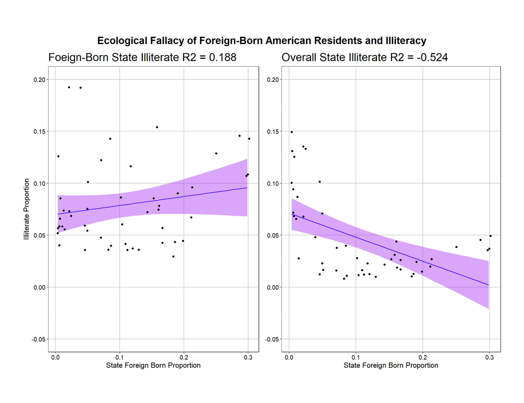

```r
add_on <- c(
  geom_point(data = illit_melt_dt[Ill_All_or_FB == fb_label], aes(x = FB_prop, y = Ill_ALL_or_FB_prop)),
  geom_point(data = illit_melt_dt[Ill_All_or_FB == overall_label], aes(x = FB_prop, y = Ill_ALL_or_FB_prop))
)

RplotterPkg::multi_scatter_plot(
  df = ols_dt,
  factor_var = "Ill_All_or_FB",
  factor_x = "FB_prop_fit",
  aes_y = "Ill_ALL_or_FB_prop_fit",
  CI_lwr = "lwr_fit",
  CI_upr = "upr_fit",
  CI_type = "ribbon",
  CI_color = "purple",
  connect = T,
  show_pts = F,
  col_width = 6,
  row_height = 8,
  y_limits = c(-0.05,0.20),
  y_major_breaks = seq(-0.05,0.20,0.05),
  show_minor_grids = F,
  rot_y_tic_label = T,
  line_color = "blue",
  title = "Ecological Fallacy of Foreign-Born American Residents and Illiteracy",
  y_titles = rep("Illiterate Proportion",2),
  x_title = "State Foreign Born Proportion",
  add_ons = add_on
)
```